# 『問題解決力を鍛える！ アルゴリズムとデータ構造』

第10章 データ構造(3)：グラフと木

[@anemptyarchive](https://www.anarchive-beta.com/)

2023-09-29 17:25:08

【編集履歴】

- 2023.09.13：執筆開始
- 2023.09.25：「ヒープ」を追加

# 10.7 二分ヒープの実装と可視化

二分木(バイナリツリー・binary tree)を用いるヒープ(二分ヒープ・binary heap)を実装します。また、ヒープ化の推移のアニメーションを作成して、アルゴリズムを確認します。  
二分木については「二分木を作図したい」を参照してください。

利用するパッケージを読み込みます。

```r
# 利用パッケージ
library(tidyverse)
library(gganimate)
```

この記事では、基本的に `パッケージ名::関数名()` の記法を使っているので、パッケージを読み込む必要はありません。ただし、作図コードについてはパッケージ名を省略しているので、`ggplot2` を読み込む必要があります。  
また、ネイティブパイプ演算子 `|>` を使っています。`magrittr` パッケージのパイプ演算子 `%>%` に置き換えても処理できますが、その場合は `magrittr` を読み込む必要があります。

「アルゴリズムの可視化」において、`gganimate` パッケージを利用してアニメーション(gif画像)を作成します。ソートの実装自体には使いません。

## ヒープ化

まずは、数列をヒープ化する操作の実装と可視化を行います。

### ヒープ化の実装

二分ヒープ化のアルゴリズムを関数として実装します。

部分木のヒープ化を実装します。

```r
# 部分木のヒープ化の実装
sub_heapify <- function(vec, i, N) {

  # 左側の子のインデックスを計算
  child_idx <- i * 2

  # 子がなければ終了
  if(child_idx > N) return(vec)

  # 値が大きい方の子のインデックスを設定
  if(child_idx+1 <= N & vec[child_idx+1] > vec[child_idx]) { # (&の左がFALSEだと右が処理されずNAにならない)
    child_idx <- child_idx + 1
  }

  # 子が親以下なら終了
  if(vec[child_idx] <= vec[i]) return(vec)

  # 子と親を入替
  vec[1:N] <- replace(x = vec, list = c(child_idx, i), values = vec[c(i, child_idx)])

  # 子を部分木の根としてヒープ化
  vec[1:N] <- sub_heapify(vec, child_idx, N)

  # 数列を出力
  return(vec)
}
```

数列を `vec`、入れ替え対象のインデックスを `i`、数列の要素数を `N` とします。  
`i` の初期値として部分木の根のインデックスを受け取ります。  
`i` 番目の頂点(要素)の2つの子の内、左側の子のインデックスを `child_idx` として計算します。頂点 $v_i$ の左側の子 $v_j$ のインデックスは $j = 2 i$ で求まります。ただし、$j \gt N$ のとき、頂点 $v_i$ に子がない(葉である)ことを意味し、入れ替え不要なので、数列をそのまま出力します。  
$j + 1 \leq N$ のとき右側の子 $v_{j+1}$ が存在するので、2つの子の値が大きい方のインデックスを `childe_idx` とします。  
子の値 `vec[child_idx]` と親の値 `vec[i]` を比較して、子が親以下なら入れ替え不要なので数列をそのまま出力(再帰処理を終了)します。子が親より大きければ値を入れ替えて、`childe_idx` 番目の頂点を根とする部分木を `sub_heapify()` でヒープ化します。

`sub_heapify()` を実行すると内部でさらに(入れ替え対象の頂点が葉になるまで再帰的に) `sub_heapify()` が実行され、親子の入れ替えが繰り返されて部分木がヒープ化されます。

アルゴリズムの詳しい解説は、本のcode 12.4(前半)などを参照してください。

木全体のヒープ化を実装します。

```r
# ヒープ化の実装
heapify <- function(vec) {

  # 要素数を取得
  N <- length(vec)

  # 葉を除くノード番号の最大値を設定
  max_i <- N %/% 2

  # 全体をヒープ化
  for(i in max_i:1) {

    # i番目の頂点を根とする部分木をヒープ化
    vec[1:N] <- sub_heapify(vec, i, N)
  }

  # 数列を出力
  return(vec)
}
```

数列を `vec`、数列の要素数を `N` とします。  
各頂点(要素)を逆順に部分木の根として、`sub_heapify()` で部分木ごとにヒープ化していきます。ただし、葉(子の無い頂点)はヒープ化不要(ヒープ化済みとみなせる)なので、末尾(N番目)の頂点の親から処理します。$N$ 番目の頂点 $v_N$ の親(葉を除く最後の頂点) $v_j$ のインデックスは $j = \lfloor \frac{N}{2} \rfloor$ で求められます。$\lfloor x \rfloor$ は、床関数(`floor()`)で、$x$ 以下の最大の整数(小数点以下の切り捨て)を表します。

アルゴリズムの詳しい解説は、本のcode 12.4(後半の一部)などを参照してください。

### ヒープの可視化

ヒープ化された数列を二分木で確認します。  
親子間のインデックスや座標の計算、バイナリツリーの作成については「二分木を作図したい」を参照してください。

要素数を指定して、数列を作成します。

```r
# 要素数を指定
N <- 20

# (簡易的に)数列を作成
a <- 1:N
a
```

```
##  [1]  1  2  3  4  5  6  7  8  9 10 11 12 13 14 15 16 17 18 19 20
```

`N` 個の値を作成します。数列のみが与えられている場合は、要素数を `N` とします。

数列をヒープ化します。

```r
# ヒープ化
a <- heapify(a)
a
```

```
##  [1] 20 19 15 18 11 13 14 17  9 10  2 12  6  3  7 16  8  4  1  5
```

1番目の要素が最大値になります。

頂点の描画用のデータフレームを作成します。

```r
# ノードの座標を作成
d <- 0.6
vertex_df <- tibble::tibble(
  value = a,
  index = 1:length(a),
  depth = floor(log2(index)), # 縦方向のノード位置
  col_idx = index - 2^depth + 1, # 深さごとのノード番号
  coord_x = (col_idx * 2 - 1) * 1/(2^depth * 2), # 横方向のノード位置
  label_offset = dplyr::if_else(
    condition = index%%2 == 0, true = 0.5+d, false = 0.5-d
  ) # ラベル位置を左右にズラす
)
vertex_df
```

```
## # A tibble: 20 × 6
##    value index depth col_idx coord_x label_offset
##    <int> <int> <dbl>   <dbl>   <dbl>        <dbl>
##  1    20     1     0       1  0.5            -0.1
##  2    19     2     1       1  0.25            1.1
##  3    15     3     1       2  0.75           -0.1
##  4    18     4     2       1  0.125           1.1
##  5    11     5     2       2  0.375          -0.1
##  6    13     6     2       3  0.625           1.1
##  7    14     7     2       4  0.875          -0.1
##  8    17     8     3       1  0.0625          1.1
##  9     9     9     3       2  0.188          -0.1
## 10    10    10     3       3  0.312           1.1
## 11     2    11     3       4  0.438          -0.1
## 12    12    12     3       5  0.562           1.1
## 13     6    13     3       6  0.688          -0.1
## 14     3    14     3       7  0.812           1.1
## 15     7    15     3       8  0.938          -0.1
## 16    16    16     4       1  0.0312          1.1
## 17     8    17     4       2  0.0938         -0.1
## 18     4    18     4       3  0.156           1.1
## 19     1    19     4       4  0.219          -0.1
## 20     5    20     4       5  0.281           1.1
```

数列とインデックスを格納して、頂点(ノード)の座標を計算します。  
また、ラベル位置の調整用の値を作成します。この例では、インデックスが偶数の場合は左にズラすために0.5以上の値、奇数の場合は右にズラすために0.5以下の値を格納しています。

辺の描画用のデータフレームを作成します。

```r
# エッジの座標を作成
edge_df <- dplyr::bind_rows(
  # 子ノードの座標
  vertex_df |>
    dplyr::filter(depth > 0) |> # 根を除去
    dplyr::mutate(
      edge_id   = index,
      node_type = "childe" # (確認用)
    ),
  # 親ノードの座標
  vertex_df |>
    dplyr::filter(depth > 0) |> # 根を除去
    dplyr::mutate(
      edge_id   = index,
      node_type = "parent", # (確認用)
      depth   = depth - 1, # 縦方向のノード位置
      index   = index %/% 2,
      col_idx = index - 2^depth + 1, # 深さごとのノード番号
      coord_x = (col_idx * 2 - 1) * 1/(2^depth * 2) # 横方向のノード位置
    )
) |>
  dplyr::select(!label_offset) |>
  dplyr::arrange(edge_id, depth)
edge_df
```

```
## # A tibble: 38 × 7
##    value index depth col_idx coord_x edge_id node_type
##    <int> <dbl> <dbl>   <dbl>   <dbl>   <int> <chr>
##  1    19     1     0       1   0.5         2 parent
##  2    19     2     1       1   0.25        2 childe
##  3    15     1     0       1   0.5         3 parent
##  4    15     3     1       2   0.75        3 childe
##  5    18     2     1       1   0.25        4 parent
##  6    18     4     2       1   0.125       4 childe
##  7    11     2     1       1   0.25        5 parent
##  8    11     5     2       2   0.375       5 childe
##  9    13     3     1       2   0.75        6 parent
## 10    13     6     2       3   0.625       6 childe
## # ℹ 28 more rows
```

数列とインデックスを格納して、辺(エッジ)の始点と終点(根を除く各頂点とその親)の座標を計算します。  
線分間が繋がらないように、子のインデックスをエッジIDとして用います。

ヒープ化した数列をバイナリツリーとして作図します。

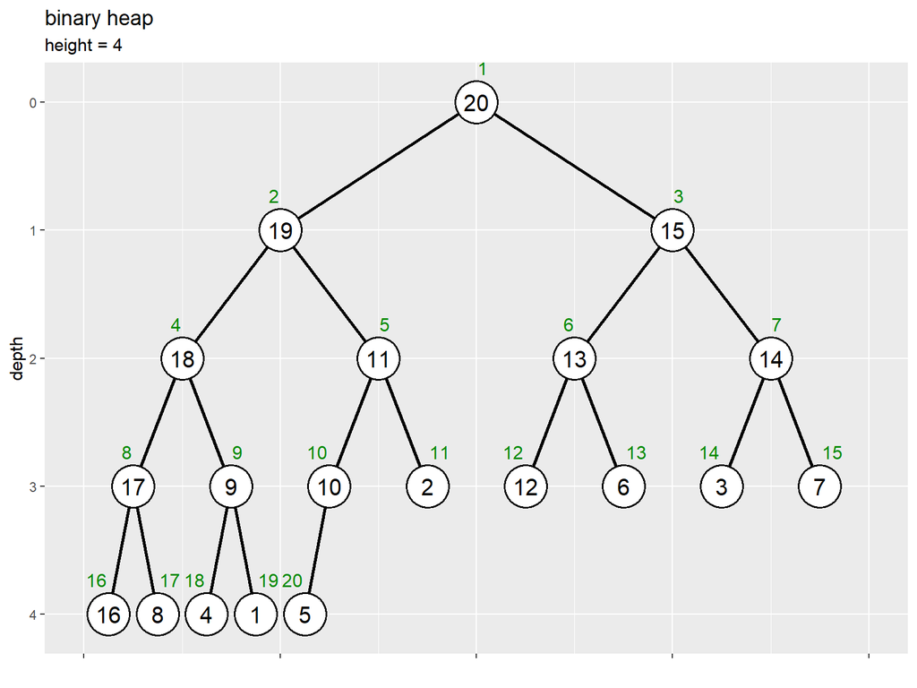

```r
# ツリーの高さを取得
max_h <- floor(log2(N))

# 二分木を作図
d <- 0.1
ggplot() +
  geom_path(data = edge_df,
            mapping = aes(x = coord_x, y = depth, group = edge_id),
            linewidth = 1) + # 辺
  geom_point(data = vertex_df,
             mapping = aes(x = coord_x, y = depth),
             size = 12, shape = "circle filled", fill = "white", stroke = 1) + # 頂点
  geom_text(data = vertex_df,
            mapping = aes(x = coord_x, y = depth, label = value),
            size = 5) + # 値ラベル
  geom_text(data = vertex_df,
            mapping = aes(x = coord_x, y = depth, label = index, hjust = label_offset),
            size = 4, vjust = -2, color = "green4") + # 位置ラベル
  scale_x_continuous(labels = NULL, name = "") +
  scale_y_reverse(breaks = 0:max_h, minor_breaks = FALSE) +
  coord_cartesian(xlim = c(0, 1), ylim = c(max_h+d, -d)) +
  labs(title = "binary heap",
       subtitle = paste0("height = ", max_h),
       y = "depth")
```

全ての親子間で親の値が子の値以上であり、根(一番上の頂点)が最大値なのを確認できます。最大値以外の要素がどの頂点(インデックス)なのかは分かりません。

### ヒープ化の可視化

二分ヒープ化のアルゴリズムをグラフで確認します。

アルゴリズムに従いヒープ化を行って、作図用のデータを作成します。

親子の値の大小関係による要素(値とインデックス)の入れ替えを関数に作成します。

```r
# 親子ノードの入替の実装
swap <- function(value, index, i, N) {

  # 数列の値・インデックスを取得
  val_vec <- value
  idx_vec <- index

  # 左側の子のインデックスを計算
  child_idx <- i * 2

  # 子がなければ終了
  if(child_idx > N) {
    lt <- list(value = val_vec, index = idx_vec, target = i)
    return(lt)
  }

  # 値が大きい方の子のインデックスを設定
  if(child_idx+1 <= N & val_vec[child_idx+1] > val_vec[child_idx]) {
    child_idx <- child_idx + 1
  }

  # 子が親以下なら終了
  if(val_vec[child_idx] <= val_vec[i]) {
    lt <- list(value = val_vec, index = idx_vec, target = i)
    return(lt)
  }

  # 子と親を入替
  val_vec[1:N] <- replace(x = val_vec, list = c(child_idx, i), values = val_vec[c(i, child_idx)])
  idx_vec[1:N] <- replace(x = idx_vec, list = c(child_idx, i), values = idx_vec[c(i, child_idx)])

  # 数列を出力
  if(child_idx <= N%/%2) {

    # 親子の入替があれば継続
    lt <- list(value = val_vec, index = idx_vec, target = child_idx)

  } else {

    # 子が葉なら終了
    lt <- list(value = val_vec, index = idx_vec, target = i)
  }
  return(lt)
}
```

数列全体と入替範囲のインデックスを受け取り、`sub_heapify()` と同様に親子の入れ替えを行い、作図用の値を出力します。再帰処理は行いません。  
作図用の値として、「数列の値・インデックス」のベクトルと「入れ替え後のインデックス」の値をリストに格納して出力します。

要素数を指定して、数列を作成します。

```r
# 要素数を指定
N <- 25

# 数列を作成
a <- sample(x = 1:N, size = N, replace = FALSE)

# 葉を除く頂点数を計算
max_i <- N %/% 2

# 数列を格納
trace_df <- tibble::tibble(
  step  = 0,   # 試行回数
  id    = 1:N, # 元のインデックス
  index = 1:N, # 各試行のインデックス
  value = a    # 要素
) |>
  dplyr::mutate(
    target_flag = FALSE, # 入替対象の頂点
    heap_flag   = index > max_i # ヒープ化済みの部分木頂点
  )
trace_df
```

```
## # A tibble: 25 × 6
##     step    id index value target_flag heap_flag
##    <dbl> <int> <int> <int> <lgl>       <lgl>
##  1     0     1     1    15 FALSE       FALSE
##  2     0     2     2     2 FALSE       FALSE
##  3     0     3     3    12 FALSE       FALSE
##  4     0     4     4    25 FALSE       FALSE
##  5     0     5     5    14 FALSE       FALSE
##  6     0     6     6    10 FALSE       FALSE
##  7     0     7     7     6 FALSE       FALSE
##  8     0     8     8    16 FALSE       FALSE
##  9     0     9     9     7 FALSE       FALSE
## 10     0    10    10     3 FALSE       FALSE
## # ℹ 15 more rows
```

乱数生成関数 `sample()` などで数値ベクトルを生成します。

1データずつ入れ替え処理を行い、数列を記録します。

```r
# 作図用のオブジェクトを初期化
id_vec <- 1:N

# ヒープ化
iter <- 0
for(i in max_i:1) {

  # i番目の頂点を設定
  target_idx <- i

  # i番目の頂点を根とする部分木をヒープ化
  swap_flag <- TRUE
  while(swap_flag) {

    # 試行回数をカウント
    iter <- iter + 1

    # 親子の値を比較・入替
    res_lt <- swap(a, id_vec, target_idx, N)
    a[1:N]      <- res_lt[["value"]]
    id_vec[1:N] <- res_lt[["index"]]
    next_target_idx <- res_lt[["target"]]

    # 数列を格納
    tmp_df <- tibble::tibble(
      step  = iter,
      id    = id_vec,
      index = 1:N,
      value = a
    ) |>
      dplyr::mutate(
        target_flag = index %in% c(target_idx, target_idx*2, target_idx*2+1), # 入替対象の親子
        heap_flag   = index >= i & !target_flag # 入替対象を除く処理済み頂点
      )

    # 結果を記録
    trace_df <- dplyr::bind_rows(trace_df, tmp_df)

    # 入替の有無を確認
    if(target_idx == next_target_idx) {

      # 入替がなければ終了
      swap_flag <- FALSE

    } else {

      # 入替があれば入替後の頂点を親として設定
      target_idx <- next_target_idx
    }

    # 途中経過を表示
    #print(paste0("--- step: ", iter, " ---"))
    #print(a)
  }
}
```

「ヒープ化の実装」のときと同様にして、要素を入れ替えていきます。再帰処理に関しては、`while()` を使って入れ替えが行われなくなるまで繰り返します。  
数列 `a` の初期値のインデックス(`1` から `N` の整数)を `id_vec` としておき、`a` の要素の入れ替えに対応するように `id_vec` の要素も入れ替えます。  
試行ごとに、数列やインデックスをデータフレームに保存します。

各試行の二分木のグラフを切り替えて推移を確認します。

試行ごとの頂点の描画用のデータフレームを作成します。

```r
# 頂点の座標を作成
trace_vertex_df <- trace_df |>
  dplyr::mutate(
    depth   = floor(log2(index)), # 縦方向の頂点位置
    col_idx = index - 2^depth + 1, # 深さごとの頂点番号
    coord_x = (col_idx * 2 - 1) * 1/(2^depth * 2), # 横方向の頂点位置
  )
trace_vertex_df
```

```
## # A tibble: 550 × 9
##     step    id index value target_flag heap_flag depth col_idx coord_x
##    <dbl> <int> <int> <int> <lgl>       <lgl>     <dbl>   <dbl>   <dbl>
##  1     0     1     1    15 FALSE       FALSE         0       1  0.5
##  2     0     2     2     2 FALSE       FALSE         1       1  0.25
##  3     0     3     3    12 FALSE       FALSE         1       2  0.75
##  4     0     4     4    25 FALSE       FALSE         2       1  0.125
##  5     0     5     5    14 FALSE       FALSE         2       2  0.375
##  6     0     6     6    10 FALSE       FALSE         2       3  0.625
##  7     0     7     7     6 FALSE       FALSE         2       4  0.875
##  8     0     8     8    16 FALSE       FALSE         3       1  0.0625
##  9     0     9     9     7 FALSE       FALSE         3       2  0.188
## 10     0    10    10     3 FALSE       FALSE         3       3  0.312
## # ℹ 540 more rows
```

各試行の数列データ `trace_df` を用いて、試行ごとに(`step` 列でグループ化して)、「ヒープの可視化」のときと同様にして、頂点の座標を計算します。

辺の描画用のデータフレームを作成します。

```r
# 辺の座標を作成
edge_df <- dplyr::bind_rows(
  # 子の座標
  trace_vertex_df |>
    dplyr::filter(step == 0, depth > 0) |> # 1試行分のデータを抽出・根を除去
    dplyr::mutate(
      edge_id = index
    ),
  # 親の座標
  trace_vertex_df |>
    dplyr::filter(step == 0, depth > 0) |> # 1試行分のデータを抽出・根を除去
    dplyr::mutate(
      edge_id = index, # 子インデックス
      depth   = depth - 1, # 縦方向の頂点位置
      index   = index %/% 2, # 親インデックス
      col_idx = index - 2^depth + 1, # 深さごとの頂点番号
      coord_x = (col_idx * 2 - 1) * 1/(2^depth * 2) # 横方向の頂点位置
    )
) |>
  dplyr::select(!step) |> # フレーム遷移の影響から外す
  dplyr::arrange(edge_id, depth)
edge_df
```

```
## # A tibble: 48 × 9
##       id index value target_flag heap_flag depth col_idx coord_x edge_id
##    <int> <dbl> <int> <lgl>       <lgl>     <dbl>   <dbl>   <dbl>   <int>
##  1     2     1     2 FALSE       FALSE         0       1   0.5         2
##  2     2     2     2 FALSE       FALSE         1       1   0.25        2
##  3     3     1    12 FALSE       FALSE         0       1   0.5         3
##  4     3     3    12 FALSE       FALSE         1       2   0.75        3
##  5     4     2    25 FALSE       FALSE         1       1   0.25        4
##  6     4     4    25 FALSE       FALSE         2       1   0.125       4
##  7     5     2    14 FALSE       FALSE         1       1   0.25        5
##  8     5     5    14 FALSE       FALSE         2       2   0.375       5
##  9     6     3    10 FALSE       FALSE         1       2   0.75        6
## 10     6     6    10 FALSE       FALSE         2       3   0.625       6
## # ℹ 38 more rows
```

1試行分(この例だと初期値)の頂点の座標データを取り出して、「ヒープの可視化」のときと同様にして、辺(始点・終点)の座標を計算します。

インデックスラベルの描画用のデータフレームを作成します。

```r
# インデックスラベルの座標を作成
d <- 0.6
index_df <- trace_vertex_df |>
  dplyr::filter(step == 0) |> # 1試行分のデータを抽出
  dplyr::mutate(
    offset = dplyr::if_else(
      condition = index%%2 == 0, true = 0.5+d, false = 0.5-d
    ) # ラベル位置を左右にズラす
  ) |>
  dplyr::select(!step) # フレーム遷移の影響から外す
index_df
```

```
## # A tibble: 25 × 9
##       id index value target_flag heap_flag depth col_idx coord_x offset
##    <int> <int> <int> <lgl>       <lgl>     <dbl>   <dbl>   <dbl>  <dbl>
##  1     1     1    15 FALSE       FALSE         0       1  0.5      -0.1
##  2     2     2     2 FALSE       FALSE         1       1  0.25      1.1
##  3     3     3    12 FALSE       FALSE         1       2  0.75     -0.1
##  4     4     4    25 FALSE       FALSE         2       1  0.125     1.1
##  5     5     5    14 FALSE       FALSE         2       2  0.375    -0.1
##  6     6     6    10 FALSE       FALSE         2       3  0.625     1.1
##  7     7     7     6 FALSE       FALSE         2       4  0.875    -0.1
##  8     8     8    16 FALSE       FALSE         3       1  0.0625    1.1
##  9     9     9     7 FALSE       FALSE         3       2  0.188    -0.1
## 10    10    10     3 FALSE       FALSE         3       3  0.312     1.1
## # ℹ 15 more rows
```

1試行分の頂点の座標データを取り出して、「ヒープの可視化」のときと同様にして、ラベル位置の調整値を追加します。

ヒープ化済みの頂点の描画用のデータフレームを作成します。

```r
# ヒープ化済み頂点の座標を作成
heap_df <- trace_vertex_df |>
  dplyr::filter(heap_flag, step > 0) |> # ヒープ化済み頂点を抽出・初期値を除去:(表示フレームの調整用)
  dplyr::mutate(
    step = step - 1 # 表示フレームを調整
  ) |>
  dplyr::bind_rows(
    trace_vertex_df |>
      dplyr::filter(step == max(step))
  ) # 最終値を追加:(表示フレームの調整用)
heap_df
```

```
## # A tibble: 406 × 9
##     step    id index value target_flag heap_flag depth col_idx coord_x
##    <dbl> <int> <int> <int> <lgl>       <lgl>     <dbl>   <dbl>   <dbl>
##  1     0    13    13    17 FALSE       TRUE          3       6  0.688
##  2     0    14    14    21 FALSE       TRUE          3       7  0.812
##  3     0    15    15     1 FALSE       TRUE          3       8  0.938
##  4     0    16    16    13 FALSE       TRUE          4       1  0.0312
##  5     0    17    17     8 FALSE       TRUE          4       2  0.0938
##  6     0    18    18    22 FALSE       TRUE          4       3  0.156
##  7     0    19    19    19 FALSE       TRUE          4       4  0.219
##  8     0    20    20     4 FALSE       TRUE          4       5  0.281
##  9     0    21    21    20 FALSE       TRUE          4       6  0.344
## 10     0    22    22    11 FALSE       TRUE          4       7  0.406
## # ℹ 396 more rows
```

各試行の頂点の座標データ `trace_vertex_df` から、各試行におけるヒープ化済み要素の座標データ(`heap_flag` 列が `TRUE` の行)を取り出します。  
1試行早く表示するために、`step` 列を-1し、最終値(全ての要素がヒープ化済み)のデータを複製します。

入れ替え対象の頂点の描画用のデータフレームを作成します。

```r
# 入替対象の頂点の座標を作成
target_vertex_df <- trace_vertex_df |>
  dplyr::filter(target_flag) |> # 入替対象の親を抽出
  dplyr::mutate(
    step = step - 1 # 表示フレームを調整
  ) |>
  dplyr::arrange(step, index)
target_vertex_df
```

```
## # A tibble: 63 × 9
##     step    id index value target_flag heap_flag depth col_idx coord_x
##    <dbl> <int> <int> <int> <lgl>       <lgl>     <dbl>   <dbl>   <dbl>
##  1     0    12    12    23 TRUE        FALSE         3       5   0.562
##  2     0    24    24     9 TRUE        FALSE         4       9   0.531
##  3     0    25    25    18 TRUE        FALSE         4      10   0.594
##  4     1    11    11    24 TRUE        FALSE         3       4   0.438
##  5     1    22    22    11 TRUE        FALSE         4       7   0.406
##  6     1    23    23     5 TRUE        FALSE         4       8   0.469
##  7     2    21    10    20 TRUE        FALSE         3       3   0.312
##  8     2    20    20     4 TRUE        FALSE         4       5   0.281
##  9     2    10    21     3 TRUE        FALSE         4       6   0.344
## 10     3    18     9    22 TRUE        FALSE         3       2   0.188
## # ℹ 53 more rows
```

各試行における入れ替え対象の座標データ(`target_flag` 列が `TRUE` の行)を取り出します。

入れ替え対象の頂点を結ぶ辺の描画用のデータフレームを作成します。

```r
# 入替対象の辺の座標を作成
target_edge_df <- dplyr::bind_rows(
  # 親の座標
  target_vertex_df |>
    dplyr::group_by(step) |>
    dplyr::filter(index == min(index)) |> # 親を抽出
    dplyr::ungroup() |>
    tidyr::uncount(weights = 2, .id = "childe_id") |> # 子の数に複製
    dplyr::mutate(
      childe_id = childe_id - 1, # 行番号を子IDに変換
      edge_id   = index * 2 + childe_id # 子インデックス
    ) |>
    dplyr::filter(edge_id <= N), # 子がなければ除去
  # 子の座標
  target_vertex_df |>
    dplyr::group_by(step) |>
    dplyr::filter(index != min(index)) |> # 子を抽出
    dplyr::ungroup() |>
    dplyr::mutate(
      edge_id = index
    )
) |>
  dplyr::arrange(step, index)
target_edge_df |>
  dplyr::select(!col_idx) # (資料作成用に間引き)
```

```
## # A tibble: 84 × 10
##     step    id index value target_flag heap_flag depth coord_x childe_id edge_id
##    <dbl> <int> <int> <int> <lgl>       <lgl>     <dbl>   <dbl>     <dbl>   <dbl>
##  1     0    12    12    23 TRUE        FALSE         3   0.562         0      24
##  2     0    12    12    23 TRUE        FALSE         3   0.562         1      25
##  3     0    24    24     9 TRUE        FALSE         4   0.531        NA      24
##  4     0    25    25    18 TRUE        FALSE         4   0.594        NA      25
##  5     1    11    11    24 TRUE        FALSE         3   0.438         0      22
##  6     1    11    11    24 TRUE        FALSE         3   0.438         1      23
##  7     1    22    22    11 TRUE        FALSE         4   0.406        NA      22
##  8     1    23    23     5 TRUE        FALSE         4   0.469        NA      23
##  9     2    21    10    20 TRUE        FALSE         3   0.312         0      20
## 10     2    21    10    20 TRUE        FALSE         3   0.312         1      21
## # ℹ 74 more rows
```

入れ替え対象の頂点の座標データ `target_vertex_df` から、入替元の頂点とその子の座標データを取り出して結合します。親のデータは、各試行におけるインデックスが最小の要素(行)で、子の数に対応するように複製します。

ヒープ化の推移のアニメーションを作成します。

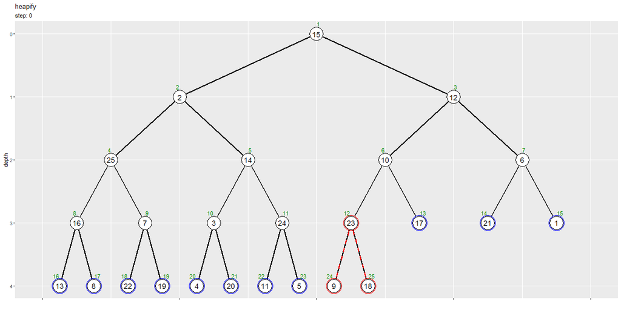

```r
# ヒープ化のアニメーションを作図
max_h <- floor(log2(N))
graph <- ggplot() +
  geom_path(data = edge_df,
            mapping = aes(x = coord_x, y = depth, group = edge_id),
            linewidth = 1) + # 辺
  geom_path(data = target_edge_df,
            mapping = aes(x = coord_x, y = depth, group = edge_id),
            color = "red", linewidth = 1, linetype = "dashed") + # 入替対象の辺
  geom_point(data = target_vertex_df,
             mapping = aes(x = coord_x, y = depth, group = step),
             size = 14, color = "red", alpha = 0.5) + # 入替対象の頂点
  geom_point(data = heap_df,
             mapping = aes(x = coord_x, y = depth, group = step),
             size = 14, color = "blue", alpha = 0.5) + # ヒープ化済みの頂点
  geom_point(data = trace_vertex_df,
             mapping = aes(x = coord_x, y = depth, group = id),
             size = 12, shape = "circle filled", fill = "white", stroke = 1) + # 頂点
  geom_text(data = trace_vertex_df,
            mapping = aes(x = coord_x, y = depth, label = as.character(value), group = id),
            size = 5) + # 値ラベル
  geom_text(data = index_df,
            mapping = aes(x = coord_x, y = depth, label = index, hjust = offset),
            size = 4, vjust = -1.7, color = "green4") + # インデックスラベル
  gganimate::transition_states(states = step, transition_length = 9, state_length = 1, wrap = FALSE) + # フレーム遷移
  gganimate::ease_aes("cubic-in-out") + # 遷移の緩急
  scale_x_continuous(labels = NULL) +
  scale_y_reverse(breaks = 0:max_h, minor_breaks = FALSE) +
  coord_cartesian(xlim = c(0, 1)) +
  labs(title = "heapify",
       subtitle = "step: {next_state}",
       x = "", y = "depth")

# フレーム数を取得
frame_num <- max(trace_df[["step"]]) + 1

# 遷移フレーム数を指定
s <- 20

# gif画像を作成
gganimate::animate(
  plot = graph,
  nframes = (frame_num + 2)*s, start_pause = s, end_pause = s, fps = 20,
  width = 1200, height = 600,
  renderer = gganimate::gifski_renderer()
)
```

`transition_states()` のフレーム制御の引数 `states` に試行回数列 `step` を指定して、これまでと同様に作図します。  
`animate()` の `plot` 引数にグラフオブジェクト、`nframes` 引数にフレーム数を指定して、gif画像を作成します。  
初期値を含むため試行回数は最大値+1です。`transition_states()` でアニメーションを作成すると、フレーム間の値を補完して、状態の遷移を描画します。遷移(1試行当たり)のフレーム数を `s` として、試行回数の `s` 倍の値を `nframes` 引数に指定します。

入れ替え対象の頂点を赤色、親子がヒープ化済みの頂点を青色の塗りつぶしで示します。

葉(子の無い頂点)を除く一番後の頂点(N番目の頂点の親)から順番に、各頂点を根として部分木をヒープ化していきます。  
部分木の根の値を子と比較して、子の方が大きければ入れ替えます。入れ替えた場合はさらに、入替先の子(元の位置からだと孫)と比較して、子の方が大きければ入れ替える操作を繰り返します。入れ替えが行われなかった場合は、次の頂点に移ります。  
「根より子の方が小さい」または「根が葉まで到達する」と、部分木がヒープ化された状態になります。この操作を後から繰り返すことで、末端の(小さな)部分木から徐々に、全体がヒープ化されるのを確認できます。

ここでの試行回数(stepの値)は、この可視化方法における試行番号(作図処理上の値)であり他の手法と対応していません。

## 値の挿入

次は、ヒープに新たな値を追加する操作の実装と可視化を行います。

### 値の挿入の実装

二分ヒープへの値の挿入のアルゴリズムを関数として実装します。

値の挿入を実装します。

```r
# 値の挿入の実装
push <- function(vec, val) {

  # 挿入要素(子)のインデックスを設定
  i <- length(vec) + 1

  # ヒープ化
  while(i > 1) { # (根に達するまで)

    # 親のインデックスを計算
    parent_idx <- i %/% 2

    # 親が子以上なら終了
    if(vec[parent_idx] >= val) break

    # 子と親を入替
    vec[i] <- vec[parent_idx] # 親の値を子の位置に移動
    i      <- parent_idx      # 挿入位置を親の位置に更新
  }

  # 値を挿入
  vec[i] <- val

  # 数列を出力
  return(vec)
}
```

ヒープ化済みの数列を `vec`、挿入する値を `val`、値の挿入位置(インデックス)を `i` とします。  
`i` の初期値として挿入後の要素数を設定します。この操作が、末尾への要素の挿入に対応します。  
`i` 番目の頂点(要素)の親のインデックスを `parent_idx` として計算します。頂点 $v_i$ の親 $v_j$ のインデックスは $j = \lfloor \frac{i}{2} \rfloor$ で求まります。

挿入する値 `val` と親の値 `vec[parent_idx]` を大小比較していき、挿入位置 `i` を探索します。  
挿入する値が大きければ、`vec` の `parent_idx` 番目の値を `i` 番目に複製し、挿入位置 `i` を `parent_idx` に更新します。この操作が、親子要素の入れ替えに対応します。ただしこの時点では、`vec` の `i, parent_idx` 番目が同じ値です。  
「親の値が挿入値以上」または「挿入位置が根(親がない)」であれば、ループ処理を終了して `vec` の `i` 番目に `val` を代入します。この操作によって入れ替えが完了します。

アルゴリズムの詳しい解説は、本のcode 10.5(前半)などを参照してください。

実装した関数を試してみます。

ヒープを作成して、値を挿入します。

```r
# 要素数を指定
N <- 25

# (簡易的に)数列を作成
a <- 1:N

# ヒープ化
a <- heapify(a)

# 挿入値を指定
x <- 23.5

# 値を挿入してヒープ化
a <- push(a, x)
a; length(a)
```

```
##  [1] 25.0 23.0 24.0 19.0 22.0 23.5 15.0 17.0 18.0 21.0 11.0 12.0 13.0 14.0  7.0
## [16] 16.0  8.0  4.0  9.0 20.0 10.0  5.0  2.0  6.0  3.0  1.0
```

```
## [1] 26
```

要素数が1つ増えます。

「ヒープの可視化」のときのコードで、新たな値を追加したヒープをバイナリツリーで確認します。

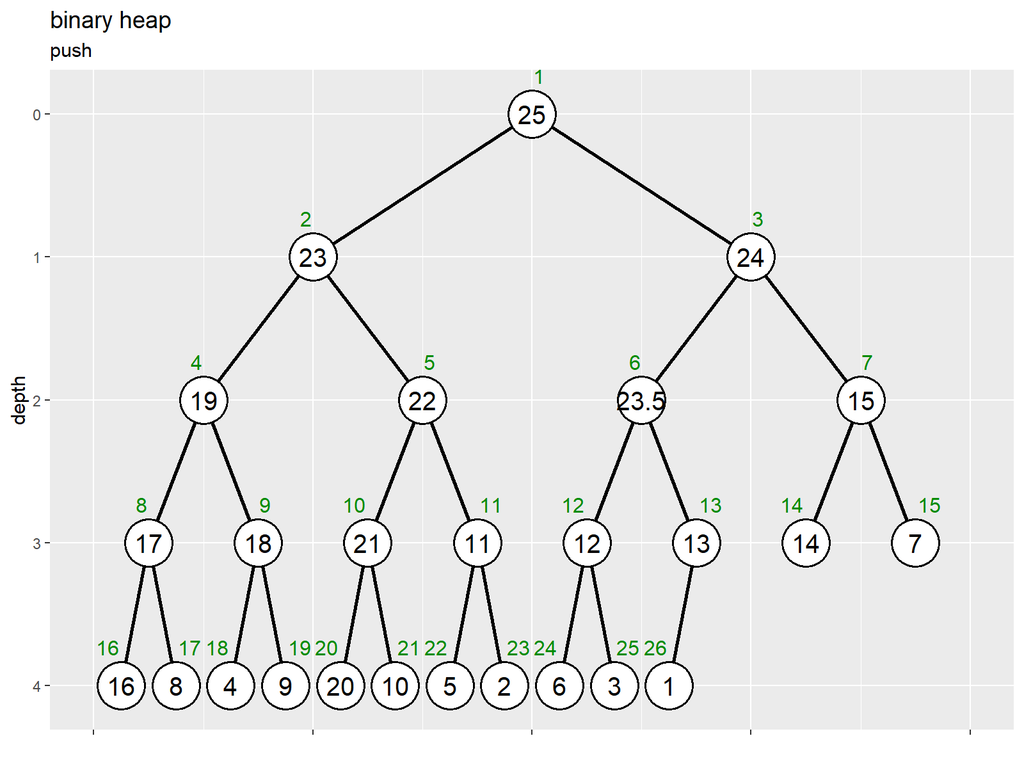

「ヒープの可視化」のときの図から、この図に変化します。

### 値の挿入の可視化

続いて、二分ヒープ化への値の挿入のアルゴリズムをグラフで確認します。

アルゴリズムに従いヒープ化を行って、作図用のデータを作成します。

要素数を指定して、ヒープを作成します。

```r
# 要素数を指定
initial_N <- 40

# ヒープを作成
initial_a <- sample(x = 1:initial_N, size = initial_N, replace = FALSE) |>
  heapify()
initial_a
```

```
##  [1] 40 39 35 38 33 32 34 37 31 24 28 25 17 27 11 29 36 23 30 22  4  1  7 12  3
## [26] 10  6 15 13  2  9 26 14  5 18 16 19  8 20 21
```

`N - 1` 個の値を作成して、`heapify()` でヒープ化します。

値を指定して、ヒープに挿入します。

```r
# 挿入する値を指定
x <- 38.5

# 値を挿入
a <- c(initial_a, x)

# 挿入後の要素数を取得
N <- length(a)
a; N
```

```
##  [1] 40.0 39.0 35.0 38.0 33.0 32.0 34.0 37.0 31.0 24.0 28.0 25.0 17.0 27.0 11.0
## [16] 29.0 36.0 23.0 30.0 22.0  4.0  1.0  7.0 12.0  3.0 10.0  6.0 15.0 13.0  2.0
## [31]  9.0 26.0 14.0  5.0 18.0 16.0 19.0  8.0 20.0 21.0 38.5
```

```
## [1] 41
```

ヒープ(数列)の末尾に値を追加します。

数列の記録用のデータフレームを作成します。

```r
# 数列を格納
trace_df <- dplyr::bind_rows(
  # 初期値
  tibble::tibble(
    step  = 0,
    id    = 1:initial_N,
    index = id,
    value = initial_a,
    target_flag = FALSE
  ),
  # 挿入後
  tibble::tibble(
    step  = 1,
    id    = 1:N,
    index = id,
    value = a,
    target_flag = index == N # 挿入対象
  )
)
trace_df
```

```
## # A tibble: 81 × 5
##     step    id index value target_flag
##    <dbl> <int> <int> <dbl> <lgl>
##  1     0     1     1    40 FALSE
##  2     0     2     2    39 FALSE
##  3     0     3     3    35 FALSE
##  4     0     4     4    38 FALSE
##  5     0     5     5    33 FALSE
##  6     0     6     6    32 FALSE
##  7     0     7     7    34 FALSE
##  8     0     8     8    37 FALSE
##  9     0     9     9    31 FALSE
## 10     0    10    10    24 FALSE
## # ℹ 71 more rows
```

初期値(挿入前)と挿入後の数列をデータフレームに格納します。

1試行ずつ入れ替え処理を行い、数列を記録します。

```r
# 挿入要素のインデックスを設定
i <- N

# 作図用のオブジェクトを初期化
id_vec <- 1:N

# ヒープ化
iter <- 1
break_flag <- FALSE
while(i > 1) {

  # 試行回数を更新
  iter <- iter + 1

  # 親のインデックスを計算
  parent_idx <- i %/% 2

  # 親のインデックスを計算
  parent_idx <- i %/% 2

  # 親が子未満なら親子を入替
  if(a[parent_idx] < a[i]) {
    a[1:N]      <- replace(x = a, list = c(i, parent_idx), values = a[c(parent_idx, i)])
    id_vec[1:N] <- replace(x = id_vec, list = c(i, parent_idx), values = id_vec[c(parent_idx, i)])
  } else {
    break_flag <- TRUE
  }

  # 数列を格納
  tmp_df <- tibble::tibble(
    step  = iter,
    id    = id_vec,
    index = 1:N,
    value = a,
    target_flag = index %in% c(i, parent_idx) # 入替対象
  )

  # 数列を記録
  trace_df <- dplyr::bind_rows(trace_df, tmp_df)

  # 親が子以上なら終了
  if(break_flag) break

  # 挿入位置を親の位置に更新
  i <- parent_idx

  # 途中経過を表示
  #print(paste0("--- step: ", iter, " ---"))
  #print(a)
}
```

「値の挿入の実装」のときと同様にして要素を入れ替えていき、試行ごとに数列やインデックスをデータフレームに保存します。

各試行の二分木のグラフを切り替えて推移を確認します。

「ヒープ化の可視化」のときのコードで、試行ごとの頂点と辺、インデックラベルの描画用のデータフレーム(`trace_vertex_df`・`edge_df`・`index_df`)を作成します。ただし、初期値(`step` 列が `0`)ではなく、挿入後(`step` 列が `1` などの値)の座標データを取り出します。

入れ替え対象の頂点と辺の描画用のデータフレームを作成します。

```r
# 入替対象の頂点の座標を作成
target_vertex_df <- trace_vertex_df |>
  dplyr::filter(target_flag) |> # 入替対象の親を抽出
  dplyr::mutate(
    step = step - 1 # 表示フレームを調整
  ) |>
  dplyr::arrange(step, index)

# 入替対象の辺の座標を作成
target_edge_df <- target_vertex_df |>
  dplyr::bind_rows(
    target_vertex_df |>
      dplyr::filter(step == 0)
  ) # (警告文回避用に挿入値を複製)
target_edge_df
```

```
## # A tibble: 10 × 8
##     step    id index value target_flag depth col_idx coord_x
##    <dbl> <int> <int> <dbl> <lgl>       <dbl>   <dbl>   <dbl>
##  1     0    41    41  38.5 TRUE            5      10   0.297
##  2     1    41    20  38.5 TRUE            4       5   0.281
##  3     1    20    41  22   TRUE            5      10   0.297
##  4     2    41    10  38.5 TRUE            3       3   0.312
##  5     2    10    20  24   TRUE            4       5   0.281
##  6     3    41     5  38.5 TRUE            2       2   0.375
##  7     3     5    10  33   TRUE            3       3   0.312
##  8     4     2     2  39   TRUE            1       1   0.25
##  9     4    41     5  38.5 TRUE            2       2   0.375
## 10     0    41    41  38.5 TRUE            5      10   0.297
```

「ヒープ化の可視化」のときのコードで `trace_vertex_df` を作成します。  
値の挿入操作では1点の座標データしかないので、挿入時(値を調整したので `step` 列が `0` の行)を複製して `target_edge_df` とします。または、挿入時のデータ(行)を取り除いて、座標データを欠損させた `step` 列が `0` の行を追加します(追加しておかないと(?)フレームの表示順がバグります)。

ヒープに値を挿入した際の推移のアニメーションを作成します。

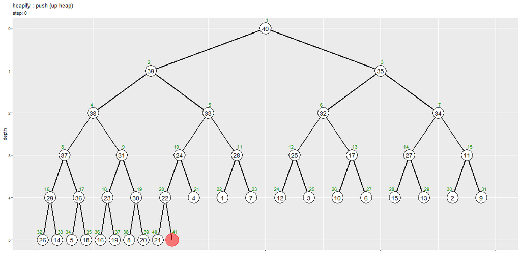

```r
# ヒープ化のアニメーションを作図
max_h <- floor(log2(N))
graph <- ggplot() +
  geom_path(data = edge_df,
            mapping = aes(x = coord_x, y = depth, group = edge_id),
            linewidth = 1) + # 辺
  geom_path(data = target_edge_df,
            mapping = aes(x = coord_x, y = depth, group = step),
            color = "red", linewidth = 1, linetype = "dashed") + # 入替対象の辺
  geom_point(data = target_vertex_df,
             mapping = aes(x = coord_x, y = depth, group = step),
             size = 14, color = "red", alpha = 0.5) + # 入替対象の頂点
  geom_point(data = trace_vertex_df,
             mapping = aes(x = coord_x, y = depth, group = id),
             size = 12, shape = "circle filled", fill = "white", stroke = 1) + # 頂点
  geom_text(data = trace_vertex_df,
            mapping = aes(x = coord_x, y = depth, label = as.character(value), group = id),
            size = 5) + # 値ラベル
  geom_text(data = index_df,
            mapping = aes(x = coord_x, y = depth, label = index, hjust = offset),
            size = 4, vjust = -1.7, color = "green4") + # インデックスラベル
  gganimate::transition_states(states = step, transition_length = 9, state_length = 1, wrap = FALSE) + # フレーム遷移
  gganimate::ease_aes("cubic-in-out") + # 遷移の緩急
  scale_x_continuous(labels = NULL) +
  scale_y_reverse(breaks = 0:max_h, minor_breaks = FALSE) +
  coord_cartesian(xlim = c(0, 1)) +
  labs(title = "heapify : push (up-heap)",
       subtitle = "step: {next_state}",
       x = "", y = "depth")

# フレーム数を取得
frame_num <- max(trace_df[["step"]]) + 1

# 遷移フレーム数を指定
s <- 20

# gif画像を作成
gganimate::animate(
  plot = graph,
  nframes = (frame_num + 2)*s, start_pause = s, end_pause = s, fps = 20,
  width = 1200, height = 600,
  renderer = gganimate::gifski_renderer()
)
```

挿入対象または入替対象の頂点を赤色の塗りつぶしで示します。

ヒープ化されている元の要素数を $N$ とすると、$N + 1$ 番目の頂点(要素)に値を追加します。ヒープ条件を満たさなくなる場合があるので、追加した値と親の値を比較・入替を繰り返します。  
ヒープ条件を満たすまで、挿入値とその親を入れ替えていくことでヒープ化されるのを確認できます。